# Color Clustering in Python

Take a look at the MARVEL logo below. you can probably figure out the most dominant colors in a second. We cleary see Black, Red & White

[figure not shown]

It's pretty easy for a human mind to pick these out But what if we wanted to write an automated script to take out the dominant colors from any imgage ? Sounds cool right ?

So thats what we're going to do today.

We will be using an algorithm called as the K-Means algorithm to automatically detect the dominant colors in the image.

## What is K-Means algorithm ?

Our goal is to partition N data points into K clusters. Each of the N data points will be assigned to a cluster with the nearest mean. The mean of each cluster is called its “centroid” or “center”.

Applying k-means will yield K separate clusters of the original n data points. Data points inside a particular cluster are considered to be “more similar” to each other than data points that belong to other clusters.

In our case, we will be clustering the pixel intensities of a RGB image. Given a MxN size image, we thus have MxN pixels, each consisting of three components: Red, Green, and Blue respectively.

We will treat these MxN pixels as our data points and cluster them using k-means.

Pixels that belong to a given cluster will be more similar in color than pixels belonging to a separate cluster.

The only facet we need to keep in mind is that we will need to provide the number of clusters, K ahead of time

# The code

We will directly jump into the code now. I'll try and explain the steps as we go through

```python
from sklearn.cluster import KMeans
import matplotlib.pyplot as plot
import argparse
import cv2
import helper
from tqdm import tqdm
```

We have imported all the dependencies needed for our project today

```python
########################
pbar = tqdm(total = 100)
########################
```

```python
ap = argparse.ArgumentParser()
ap.add_argument("-i", "--image", required = True, default = "/Users/Interface/Coding 2/CV/color_clustering_kmeans/test3.jpeg")
ap.add_argument("-c", "--clusters", required = True, type = int, default = 4)
args = vars(ap.parse_args())
```

We have added the CLI(commmand line) argument parser. Now we can send the arguments directly at the cli while running the script.

This is completely optional and I'll add the values inline for the sake of this article.

[figure not shown]

```python
# image = cv2.imread(args["image"])
image = cv2.imread("/Users/Interface/Coding 2/CV/color_clustering_kmeans/test1.png")
image = cv2.cvtColor(image, cv2.COLOR_BGR2RGB)

########################
pbar.update(10)
########################

plot.figure()
plot.axis("off")
plot.imshow(image)

image = image.reshape(image.shape[0] * image.shape[1], 3);
```

Here, we have fetched the image and converted that to RGB color channel. An important point to note here is that, openCV and most other image processing or Computer Vision frameworks take images in BGR channel and not RGB

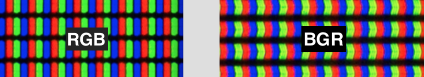

Now, an image is basically MxN matrix of pixels. We are simply re-shaping our NumPy array to be a list of RGB pixels. So that we can run our algorithm on the image

```python
########################
pbar.update(20)
########################

# clt = KMeans(n_clusters = args["clusters"])
clt = KMeans(n_clusters = 3)
clt.fit(image)

########################
pbar.update(40)
########################
```

```
110it [03:15,  1.87s/it]
```

But, we do need to define some helper functions to help us display the dominant colors of the image. So, let's open up a new file and name it helper.py

```python
import cv2
import numpy as np

maxc = list()

def centroid_histogram(clt) :

        clusters = np.arange(0, len(np.unique(clt.labels_)) + 1)
        (hist, _) = np.histogram(clt.labels_, bins = clusters)

        hist = hist.astype("float")
        hist /= hist.sum()

        return hist

def plot_colors(hist, centroids) :

        bar = np.zeros((50,300, 3), dtype = "uint8")
        startx = 0

        for (percent, color) in zip(hist, centroids) :
                print(percent)
                maxc.append(percent)
                endx = startx + (percent * 300)
                cv2.rectangle(bar, (int(startx), 0), (int(endx), 50), color.astype("uint8").tolist(), -1)
                startx = endx

        plot_max()

        return bar

def plot_max() :

        maxbar = np.zeros((50,50,3), dtype = "uint8")

        x = np.amax(maxc)
        cv2.rectangle(maxbar, (0,0), (50,50), x, -1)

        return maxbar
```

In the first function, we take the number of clusters and then create a Histogram based on the number of pixels assigned to each cluster

In the second function, we send 2 parameters - the histogram returned from the first function and then a list of all centroids returned by the K-Means algorithm We calculate the average percentage of each color assigned to each color. Which gives us a percentage breakdown of the dominant colors

```python
hist = helper.centroid_histogram(clt)
bar = helper.plot_colors(hist, clt.cluster_centers_)
maxbar = helper.plot_max()

########################
pbar.update(30)
pbar.close()
########################
```

```
140it [03:33,  1.67s/it]
```

```
0.1871031746031746
0.6826190476190476
0.13027777777777777
```

Now, we have glued everything together since the helper functions are done

[figure not shown]

```python
p = plot.figure()
p2 = p.add_subplot(211)
p2.axis("off")
p2.imshow(bar)

p3 = p.add_subplot(212)
p3.axis("off")
p3.imshow(maxbar)
plot.show()
```

If you'd like to run it through it CLI, all you need to do is -

`python k-means_clustering.py --image test3.jpeg --clusters 4`

This is a sample illustration for the cli with 4 clusters

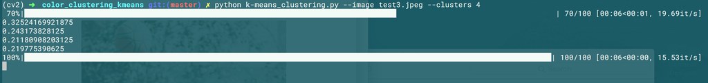

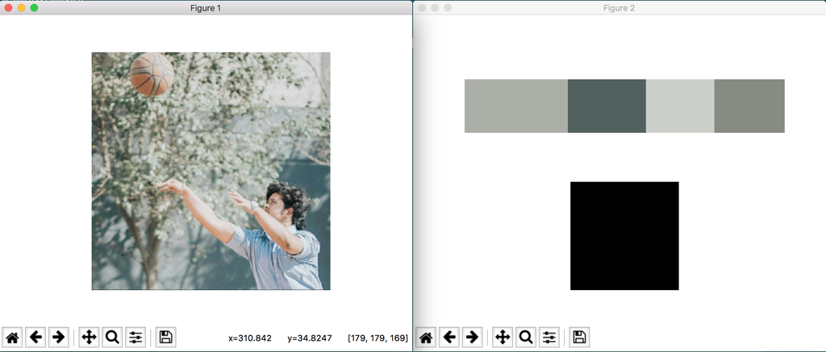

So there you have it!

We have successfully used openCV and Python to cluster RGB pixels and extract the most dominant colors in an image